# Week 5B Getting Data Part 1: Working with APIs

Oct 1, 2020

## Week #5 Agenda

**Last time**:

- Introduction to APIs
- Pulling census data and shape files using Python

**Today:**

- API Example: Lead poisoning in Philadelphia
- Using the Twitter API
  - Plotting geocoded tweets
  - Word frequencies
  - Sentiment analysis

```python
import geopandas as gpd
import pandas as pd
import numpy as np
from shapely.geometry import Point

from matplotlib import pyplot as plt
import seaborn as sns

import hvplot.pandas
import holoviews as hv

hv.extension("bokeh")
%matplotlib inline
```

```python
import carto2gpd
import cenpy
```

## Last time: Querying the census with cenpy

First, let's initialize a connection to the 2018 5-year ACS dataset

```python
acs = cenpy.remote.APIConnection("ACSDT5Y2018")
```

```python
# Set the map service for pulling geometries
acs.set_mapservice("tigerWMS_ACS2018")
```

[output not shown]

## Exercise: lead poisoning in Philadelphia

Let's use demographic census data in Philadelphia by **census tract** and compare to a dataset of childhood lead poisoning.

### Step 1. Download the demographic data for Philadelphia

- We are going to be examining the percent of the population that identifies as black in each census tract, so we will need:
  - Total population: 'B03002_001E'
  - Non-Hispanic, Black population: 'B03002_004E'
- You'll want to use the state --> county --> tract hierarchy , using the `*` operator to get all tracts in Philadelphia county
- Remember PA has a FIPS code of "42" and Philadelphia County is "101"

### Step 2. Download and merge in the census tract geometries

### Step 3. Calculate the black percentage

Add a new column to your data called `percent_black`.

**Important:** Make sure you convert the data to floats!

### Step 4. Query CARTO to get the childhood lead levels by census tract

- The API documentation for this data is here: https://cityofphiladelphia.github.io/carto-api-explorer/#child_blood_lead_levels_by_ct
- You can use the `carto2gpd` package
  - You'll need the API endpoint for CARTO and the name of the table

### Step 5. Remove census tracts with missing lead measurements

See the `.dropna()` function and the `subset=` keyword.

### Step 6. Merge the demographic and lead level data frames

- From the lead data, we only need the 'census_tract' and 'perc_5plus'. Before merging, trim your data to only these columns.
- You can perform the merge by comparing the `census_tract` and `GEOID` fields
- Remember: when merging, the left data frame should be the GeoDataFrame — use `GeoDataFrame.merge(...)`

### Step 7. Trim to the columns we need

We only need the 'geometry', 'percent_black', and 'perc_5plus', and 'NAME' columns

### Step 8. Plot the results

Make two plots:

1. A two panel, side-by-side chart showing a choropleth of the lead levels and the percent black
2. A scatter plot showing the percentage

You can make these using hvplot or geopandas/matplotlib — whichever you prefer!

### Step 9. Use seaborn to plot a 2d density map

In the previous plots, it's still hard to see the relationship. Use the `kdeplot()` function in `seaborn` to better visualize the relationship.

You will need to remove any NaN entries first.

You should see two peaks in the distribution clearly now!

## API Example #2: the Twitter API

Twitter provides a rich source of information, but the challenge is how to extract the information from **semi-structured** data.

## Semi-structured data

Data that contains some elements that cannot be easily consumed by computers

**Examples:** human-readable text, audio, images, etc

## Key challenges

- **Text mining**: analyzing blocks of text to extract the relevant pieces of information
- **Natural language processing (NLP)**: programming computers to process and analyze human languages
- **Sentiment analysis**: analyzing blocks of text to derive the attitude or emotional state of the person

## First: Getting an API key

### Step 1: Make a Twitter account

### Step 2: Apply for Developer access

See: https://developer.twitter.com/apps

You will need to apply for a Developer Account, answering a few questions, and then confirm your email address.

Once you submit you'll application, you'll need to wait for approval...usually this happens immediately, but there can sometimes be a short delay

### Sample answer

**Needs to be at least 300 characters**

### Step 3: Create a new app

https://developer.twitter.com/en/apps/create

### Step 4: Create your API keys

In the "Keys and Tokens" section, generate new access tokens.

You will need the Consumer API keys and access tokens to use the Twitter API.

## We'll be using `tweepy` to search recent tweets

The standard, free API let's you search tweets from the last 7 days

For more information, see the [Twitter Developer docs](https://developer.twitter.com/en/docs/basics/getting-started)

## Tweepy: a Python interface to Twitter

https://tweepy.readthedocs.io

```python
import tweepy as tw
```

## Define your API keys

```python
# INPUT YOUR API AND ACCESS KEYS HERE
api_key = ""
api_key_secret = ""
access_token = ""
access_token_secret = ""
```

## Initialize an API object

We need to:

- step up authentication
- intialize a `tweepy.API` object

```python
auth = tw.OAuthHandler(api_key, api_key_secret)
auth.set_access_token(access_token, access_token_secret)
api = tw.API(auth, wait_on_rate_limit=True)
```

## Rate Limits

See the [Rate Limits](https://developer.twitter.com/en/docs/basics/rate-limiting.html) documentation for more details.

## What does `wait_on_rate_limit` do?

If you run into a rate limit while pulling tweets, this will tell `tweepy` to wait 15 minutes until it can continue.

Unfortunately, you need to sign up (and pay) for the [premium API](https://developer.twitter.com/en/premium-apis.html) to avoid these rate limits.

## How to find out how many requests you've made?

```python
data = api.rate_limit_status()
```

```python
data
```

[output not shown]

[output cut: 430 more lines]

```
   '/oauth/revoke_html': {'limit': 15, 'remaining': 15, 'reset': 1601514664}},
  'search': {'/search/tweets': {'limit': 180,
    'remaining': 180,
    'reset': 1601514664}},
  'trends': {'/trends/closest': {'limit': 75,
    'remaining': 75,
    'reset': 1601514664},
   '/trends/available': {'limit': 75, 'remaining': 75, 'reset': 1601514664},
   '/trends/place': {'limit': 75, 'remaining': 75, 'reset': 1601514664}},
  'live_pipeline': {'/live_pipeline/events': {'limit': 180,
    'remaining': 180,
    'reset': 1601514664}},
  'graphql': {'/graphql': {'limit': 15,
    'remaining': 15,
    'reset': 1601514664}}}}
```

```python
data['resources']['search']
```

```
{'/search/tweets': {'limit': 180, 'remaining': 180, 'reset': 1601514664}}
```

## Tip: converting a time stamp to a date

```python
import datetime
datetime.datetime.fromtimestamp(1601514664)
```

```
datetime.datetime(2020, 9, 30, 21, 11, 4)
```

## Several different APIs available

Including user tweets, mentions, searching keywords, favoriting, direct messages, and more...

See the [Tweepy API documentation](https://tweepy.readthedocs.io/en/3.7.0/api.html)

## You can also stream tweets

You can set up a **listener** to listen for new tweets and download them in real time (subject to rate limits).

We won't focus on this, but there is a nice [tutorial](https://tweepy.readthedocs.io/en/3.7.0/streaming_how_to.html) on the Tweepy documentation.

## You can also tweet (if you want!)

You can post tweets using the `update_status()` function. For example:

```
tweet = 'Hello World! @PennMusa'
api.update_status(tweet)
```

## We'll focus on the search API

We'll use a `tweepy.Cursor` object to query the API.

```python
# collect tweets related to the phillies
search_words = "#phillies"
```

```python
# initialize the cursor
cursor = tw.Cursor(api.search,
                   q=search_words,
                   lang="en",
                   tweet_mode='extended')
cursor
```

```
<tweepy.cursor.Cursor at 0x7ffeb80d4750>
```

## Next, specify how many tweets we want

Use the `Cursor.items()` function:

```python
# select 5 tweets
tweets = cursor.items(5)
tweets
```

```
<tweepy.cursor.ItemIterator at 0x7ffeb80c8e10>
```

## Python iterators

As the name suggests, **iterators** need to be iterated over to return objects. In our case, we can use a for loop to iterate through the tweets that we pulled from the API.

```python
# Iterate on tweets
for tweet in tweets:
    print(tweet.full_text)
```

```
Filly en' full affect I see .. #phillies
RT @theaceofspaeder: I still cannot believe that the #Phillies led in 49 of 60 games, yet are not playing in the #postseason.
RT @BigHairPlasGras: A funky farewell to the great Jay Johnstone - legendary prankster, utility man extraordinaire, 2x WS winner with the #…
RT @a2dradio_com: Should Alec Bohm be the NL rookie of the year?

#Phillies | #AlecBohm | #MLB | #RingTheBell https://t.co/ryC4QucxRX
Philadelphia Phillies Trading Cards with FREE Protective Card Sleeves - MIX LOT of players active between 1980-Present (NO DUPLICATES!  –
Available Now to Order Here:
https://t.co/EeVoT67TXX
#Phillies #BaseballCards #TradingCards #ClassicMLB #MLB
https://t.co/j8bwokO06w
```

## The concept of "paging"

**Unfortunately, there is no way to search for tweets between specific dates.**

The API pulls tweets from the most recent page of the search result, and then grabs tweets from the previous page, and so on, to return the requested number of tweets.

## Customizing our search query

The [API documentation](https://developer.twitter.com/en/docs/tweets/rules-and-filtering/overview/standard-operators) has examples of different query string use cases

## Examples

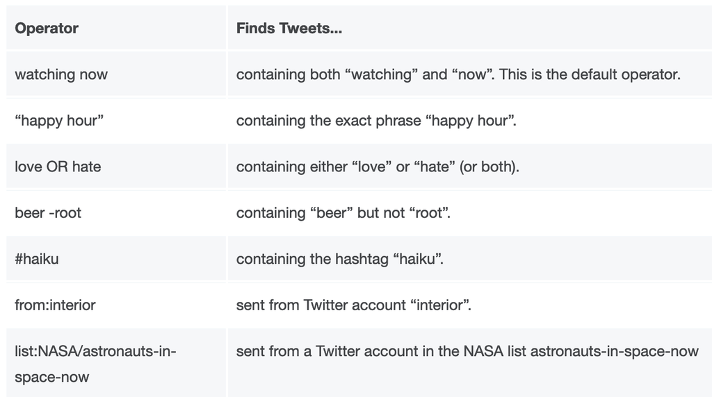

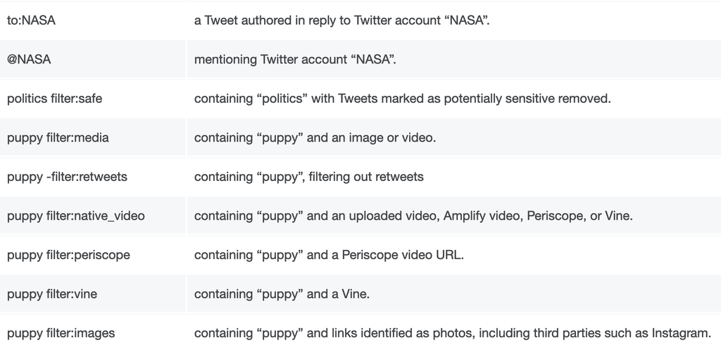

## Let's remove retweets

```python
new_search = search_words + " -filter:retweets"
```

Get a new tweets using our new search query:

```python
cursor = tw.Cursor(api.search,
                   q=new_search,
                   lang="en",
                   tweet_mode='extended')
tweets = cursor.items(5)
```

## Did it work?

```python
for tweet in tweets:
    print(tweet.full_text)
```

```
Filly en' full affect I see .. #phillies
Philadelphia Phillies Trading Cards with FREE Protective Card Sleeves - MIX LOT of players active between 1980-Present (NO DUPLICATES!  –
Available Now to Order Here:
https://t.co/EeVoT67TXX
#Phillies #BaseballCards #TradingCards #ClassicMLB #MLB
https://t.co/j8bwokO06w
Whether he's bad or unlucky, #Phillies must hold Matt Klentak accountable, writes Jay Dunn https://t.co/Wsz5HoyWL8
@phillies you need GM Benny breeze to fix your farm system and team!  He's a little under the radar but he's way batter and cheaper than what you got. Hit me up for his number!  #phillies
The #Phillies know too well. If only we had a hard-throwing Sixto Sanchez in our farm sys...oh, um, yeah... 😥 https://t.co/NaXWWbIOHk
```

## How to save the tweets?

Create a list of the tweets using Python's inline syntax

```python
# select the next 10 tweets
tweets = [t for t in cursor.items(10)]

print(len(tweets))
```

```
10
```

## A wealth of information is available

Beyond the text of the tweet, things like favorite and retweet counts are available. You can also extract info on the user behind the tweet.

```python
first_tweet = tweets[0]
```

```python
first_tweet.full_text
```

```
'😍OTD 2009: Phillies clinch 3rd straight division title with 10-3 W over HOU. During the celebration, players went to the H of K sign on the LF wall. Harry Kalas died earlier in the season. Very touching moment. (https://t.co/s81XVvKf4c) #phillies https://t.co/SxFPGcLT4v'
```

```python
first_tweet.favorite_count
```

```
19
```

```python
first_tweet.created_at
```

```
datetime.datetime(2020, 9, 30, 21, 40, 17)
```

```python
first_tweet.retweet_count
```

```
4
```

```python
first_tweet.user.description
```

```
"Larry (Baron) Shenk started with Phillies in 1964. Retired in 2015. Hobby: Phillies. Can't swim, don't play golf or sky dive."
```

```python
first_tweet.user.followers_count
```

```
4478
```

## Let's extract screen names and locations

A fraction of tweets have locations associated with user profiles, giving (very rough) location data.

```python
users_locs = [[tweet.user.screen_name, tweet.user.location] for tweet in tweets]
users_locs
```

```
[['ShenkLarry', ''],
 ['1490SportsBet', 'Atlantic City, NJ '],
 ['Phil_E_Phanatic', 'Philly'],
 ['1490SportsBet', 'Atlantic City, NJ '],
 ['CKit_Eph2_8', 'Guntersville, AL'],
 ['harrymayesTU', 'Pennsylvania, USA'],
 ['InThe700', 'South Philadelphia'],
 ['viejas46', 'VA Beach'],
 ['RobMaaddi', 'Philadelphia, PA'],
 ['MrUram', 'Philadelphia']]
```

**Note**: only about 1% of tweets have a latitude/longitude.

Difficult to extract geographic trends without pulling a large number of tweets, requiring a premium API.

## Use case #1: calculating word frequencies

An example of **text mining**

## Load the most recent 1,000 tweets

Save the text of 1,000 tweets after querying our cursor object.

```python
cursor = tw.Cursor(api.search,
                   q="#phillies -filter:retweets",
                   lang="en",
                   tweet_mode='extended')
tweets = [tweet for tweet in cursor.items(1000)]
```

```python
# get the text of the tweets
tweets_text = [tweet.full_text for tweet in tweets]
```

```python
# the first five tweets
tweets_text[:5]
```

```
["Filly en' full affect I see .. #phillies",
 'Philadelphia Phillies Trading Cards with FREE Protective Card Sleeves - MIX LOT of players active between 1980-Present (NO DUPLICATES!  – \nAvailable Now to Order Here: \nhttps://t.co/EeVoT67TXX\n#Phillies #BaseballCards #TradingCards #ClassicMLB #MLB\nhttps://t.co/j8bwokO06w',
 "Whether he's bad or unlucky, #Phillies must hold Matt Klentak accountable, writes Jay Dunn https://t.co/Wsz5HoyWL8",
 "@phillies you need GM Benny breeze to fix your farm system and team!  He's a little under the radar but he's way batter and cheaper than what you got. Hit me up for his number!  #phillies",
 'The #Phillies know too well. If only we had a hard-throwing Sixto Sanchez in our farm sys...oh, um, yeah... 😥 https://t.co/NaXWWbIOHk']
```

## Text mining and dealing with messy data

1. Remove URLs $\rightarrow$ regular expressions
2. Remove **stop words**
3. Remove the search terms

## Step 1: removing URLs

### Regular expressions

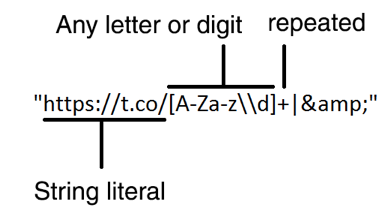

This will identify "t.co" in URLs, e.g. https://t.co/Sp1Qtf5Fnl

Don't worry about mastering regular expression syntax...

StackOverflow is your friend

```python
def remove_url(txt):
    """
    Replace URLs found in a text string with nothing
    (i.e. it will remove the URL from the string).

    Parameters
    ----------
    txt : string
        A text string that you want to parse and remove urls.

    Returns
    -------
    The same txt string with url's removed.
    """
    import re
    return " ".join(re.sub("https://t.co/[A-Za-z\\d]+|&amp", "", txt).split())
```

## Remove any URLs

```python
tweets_no_urls = [remove_url(tweet) for tweet in tweets_text]
tweets_no_urls[:5]
```

```
["Filly en' full affect I see .. #phillies",
 'Philadelphia Phillies Trading Cards with FREE Protective Card Sleeves - MIX LOT of players active between 1980-Present (NO DUPLICATES! – Available Now to Order Here: #Phillies #BaseballCards #TradingCards #ClassicMLB #MLB',
 "Whether he's bad or unlucky, #Phillies must hold Matt Klentak accountable, writes Jay Dunn",
 "@phillies you need GM Benny breeze to fix your farm system and team! He's a little under the radar but he's way batter and cheaper than what you got. Hit me up for his number! #phillies",
 'The #Phillies know too well. If only we had a hard-throwing Sixto Sanchez in our farm sys...oh, um, yeah... 😥']
```

## Extract a list of lower-cased words in a tweet

- `.lower()` makes all words lower cased
- `.split()` splits a string into the individual words

```python
"This is an Example".lower()
```

```
'this is an example'
```

```python
"This is an Example".lower().split()
```

```
['this', 'is', 'an', 'example']
```

Apply these functions to all tweets:

```python
words_in_tweet = [tweet.lower().split() for tweet in tweets_no_urls]
words_in_tweet[:2]
```

```
[['filly', "en'", 'full', 'affect', 'i', 'see', '..', '#phillies'],
 ['philadelphia',
  'phillies',
  'trading',
  'cards',
  'with',
  'free',
  'protective',
  'card',
  'sleeves',
  '-',
  'mix',
  'lot',
  'of',
  'players',
  'active',
  'between',
  '1980-present',
  '(no',
  'duplicates!',
  '–',
  'available',
  'now',
  'to',
  'order',
  'here:',
  '#phillies',
  '#baseballcards',
  '#tradingcards',
  '#classicmlb',
  '#mlb']]
```

## Counting word frequencies

We'll define a helper function to calculate word frequencies from our lists of words.

```python
def count_word_frequencies(words_in_tweet, top=15):
    """
    Given a list of all words for every tweet, count
    word frequencies across all tweets.

    By default, this returns the top 15 words, but you
    can specify a different value for `top`.
    """
    import itertools, collections

    # List of all words across tweets
    all_words = list(itertools.chain(*words_in_tweet))

    # Create counter
    counter = collections.Counter(all_words)

    return pd.DataFrame(counter.most_common(top),
                        columns=['words', 'count'])
```

```python
counts_no_urls = count_word_frequencies(words_in_tweet, top=15)
counts_no_urls.head(n=10)
```

|  | words | count |
| --- | --- | --- |
| 0 | the | 1310 |
| 1 | #phillies | 939 |
| 2 | to | 517 |
| 3 | a | 473 |
| 4 | and | 437 |
| 5 | in | 406 |
| 6 | of | 330 |
| 7 | for | 243 |
| 8 | is | 193 |
| 9 | i | 177 |

## Now let's plot the frequencies

Use `seaborn` to plot our DataFrame of word counts...

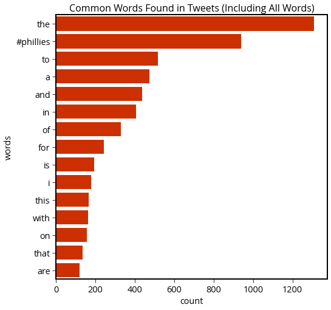

```python
fig, ax = plt.subplots(figsize=(8, 8))

# Plot horizontal bar graph
sns.barplot(
    y="words",
    x="count",
    data=counts_no_urls.sort_values(by="count", ascending=False),
    ax=ax,
    color="#cc3000",
    saturation=1.0,
)

ax.set_title("Common Words Found in Tweets (Including All Words)", fontsize=16)
```

## Step 2: remove stop words and punctuation

Common words that do not carry much significance and are often ignored in text analysis.

We can use the `nltk` package.

The "Natural Language Toolkit" https://www.nltk.org/

## Import and download the stop words

```python
import nltk
nltk.download('stopwords');
```

## Get the list of common stop words

```python
stop_words = list(set(nltk.corpus.stopwords.words('english')))

stop_words[:10]
```

```
['such', 'd', 'does', 'ours', 'those', 'too', "hadn't", 'isn', 'all', 'is']
```

## Get the list of common punctuation

```python
import string
```

```python
punctuation = list(string.punctuation)
```

```python
punctuation[:5]
```

```
['!', '"', '#', '$', '%']
```

## Remove stop words from our tweets

```python
ignored = stop_words + punctuation
```

```python
# Remove stop words from each tweet list of words
tweets_nsw = [[word for word in tweet_words if word not in ignored]
              for tweet_words in words_in_tweet]

tweets_nsw[0]
```

```
['filly', "en'", 'full', 'affect', 'see', '..', '#phillies']
```

## Get our DataFrame of frequencies

```python
counts_nsw = count_word_frequencies(tweets_nsw)
counts_nsw.head()
```

|  | words | count |
| --- | --- | --- |
| 0 | #phillies | 939 |
| 1 | season | 119 |
| 2 | klentak | 118 |
| 3 | #eagles | 114 |
| 4 | #ringthebell | 103 |

And plot...

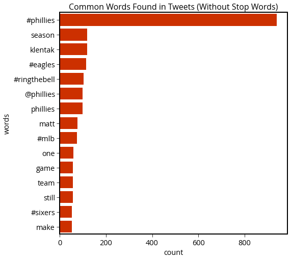

```python
fig, ax = plt.subplots(figsize=(8, 8))

sns.barplot(
    y="words",
    x="count",
    data=counts_nsw.sort_values(by="count", ascending=False),
    ax=ax,
    color="#cc3000",
    saturation=1.0,
)

ax.set_title("Common Words Found in Tweets (Without Stop Words)", fontsize=16);
```

## Step 3: remove our query terms

Now, we'll be left with only the **meanigful** words...

```python
search_terms = ['#phillies', "phillies", "@phillies"]
tweets_final = [[w for w in word if w not in search_terms]
                 for word in tweets_nsw]
```

```python
# frequency counts
counts_final = count_word_frequencies(tweets_final)
```

## And now, plot the cleaned tweets...

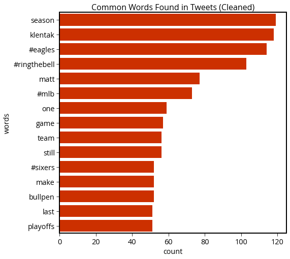

```python
fig, ax = plt.subplots(figsize=(8, 8))

sns.barplot(
    y="words",
    x="count",
    data=counts_final.sort_values(by="count", ascending=False),
    ax=ax,
    color="#cc3000",
    saturation=1.0,
)

ax.set_title("Common Words Found in Tweets (Cleaned)", fontsize=16)
```

## At home exercise

Get 1,000 tweets using a query string of your choice and plot the word frequencies.

Be sure to:

- remove URLs
- remove stop words / punctuation
- remove your search query terms

**Note**: if you try to pull more than 1,000 tweets you will likely run into the rate limit and have to wait 15 minutes.

**Remember:** the [API documentation](https://developer.twitter.com/en/docs/tweets/rules-and-filtering/overview/standard-operators) describes how to customize a query string.

## Use case #2: sentiment analysis

The goal of a **sentiment analysis** is to determine the attitude or emotional state of the person who sent a particular tweet.

Often used by brands to evaluate public opinion about a product.

## The goal:

Determine the "sentiment" of every word in the English language

## The hard way

Train a machine learning algorithm to classify words as positive vs. negative, given an input training sample of words.

## The easy way

Luckily, this is a **very common** task in NLP and there are several packages available that have done the hard work for you.

They provide out-of-the-box sentiment analysis using pre-trained machine learning algorithms.

## We'll be using `textblob`

```python
import textblob
```

## Let's analyze our set of 1,000 #phillies tweets

## Create our "text blobs"

Simply pass the tweet text to the `TextBlob()` object.

**Note:** it's best to remove any URLs first!

```python
blobs = [textblob.TextBlob(remove_url(t.full_text)) for t in tweets]
```

```python
blobs[0]
```

```
TextBlob("Filly en' full affect I see .. #phillies")
```

```python
blobs[0].sentiment
```

```
Sentiment(polarity=0.35, subjectivity=0.55)
```

## Combine the data into a DataFrame

Track the polarity, subjectivity, and date of each tweet.

```python
data = {}
data['date'] = [t.created_at for t in tweets]
data['polarity'] = [b.sentiment.polarity for b in blobs]
data['subjectivity'] = [b.sentiment.subjectivity for b in blobs]
data['text'] = [remove_url(t.full_text) for t in tweets]
data = pd.DataFrame(data)
```

```python
data.head()
```

|  | date | polarity | subjectivity | text |
| --- | --- | --- | --- | --- |
| 0 | 2020-10-01 00:59:44 | 0.350000 | 0.550000 | Filly en' full affect I see .. #phillies |
| 1 | 2020-10-01 00:50:00 | 0.211111 | 0.600000 | Philadelphia Phillies Trading Cards with FREE ... |
| 2 | 2020-09-30 23:57:55 | -0.700000 | 0.666667 | Whether he's bad or unlucky, #Phillies must ho... |
| 3 | 2020-09-30 23:35:18 | -0.234375 | 0.500000 | @phillies you need GM Benny breeze to fix your... |
| 4 | 2020-09-30 23:28:06 | 0.000000 | 1.000000 | The #Phillies know too well. If only we had a ... |

## How many are unbiased?

We can remove tweets with a polarity of zero to get a better sense of emotions.

```python
zero = (data['polarity']==0).sum()
print("number of unbiased tweets = ", zero)
```

```
number of unbiased tweets =  359
```

```python
# remove unbiased tweets
biased = data.loc[ data['polarity'] != 0 ].copy()
```

## What does a polarized tweet look like?

We can find the tweet with the maximum positive/negative scores

### The most negative

Use the `idxmin()` function:

```python
biased.loc[biased['polarity'].idxmin(), 'text']
```

```
"September 2020 was the worst month in Philly sports history. #Sixers were already done and watched Jimmy Butler go to the Finals. The #Flyers hit the wall. The #Eagles couldn't even beat the Bengals, and it was another September swoon for the #Phillies. Change my mind. @Sec215"
```

### The most positive

Use the `idxmax()` function

```python
biased.loc[biased['polarity'].idxmax(), 'text']
```

```
"MLB's best top-of-the-rotation duos, by WAR (fangraphs): T1) Reds (Bauer, Castillo) 4.9 T1) Cubs (Darvish, Hendricks) 4.9 3) Indians (Bieber, Carrasco) 4.7 4) Brewers (Burnes, Woodruff) 4.5 5) Mets (deGrom, Porcello) 4.2 6) #Phillies (Nola, Wheeler) 4.0 @TheGoodPhight"
```

## Plot a histogram of polarity

We can use matplotlib's `hist()` function:

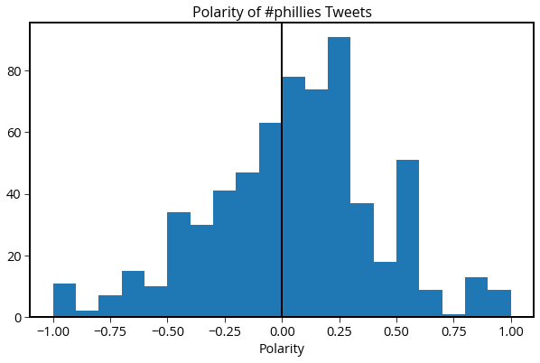

```python
# create a figure and axes
fig, ax = plt.subplots(figsize=(10, 6))

# histogram
ax.hist(biased['polarity'], bins='auto')
ax.axvline(x=0, c='k', lw=2)

# format
ax.set_xlabel("Polarity")
ax.set_title("Polarity of #phillies Tweets", fontsize=16);
```

## And subjectivity too...

### The most objective

```python
biased.loc[biased['subjectivity'].idxmin(), 'text']
```

```
'Literally don’t know what was harder to watch the #Phillies bullpen this season or the #Debates2020 #PresidentialDebate2020 JESUS. I can’t believe this is what it has come to, can’t even vote but WHERES BERNIE?!?'
```

### The most subjective

```python
biased.loc[biased['subjectivity'].idxmax(), 'text']
```

```
"1981 Season Replay #Pirates (26-41) vs #Phillies (41-28) Bake McBride and Keith Moreland drive in 2 each as the Phillies beat up the Pirates 7-1. Ruthven scatters 6 hits. Parker homers for the lone Pirates run. WP: Dick Ruthven (9-5) LP: Jim Bibby (4-7) HR's: Dave Parker (8)"
```

## The distribution of subjectivity

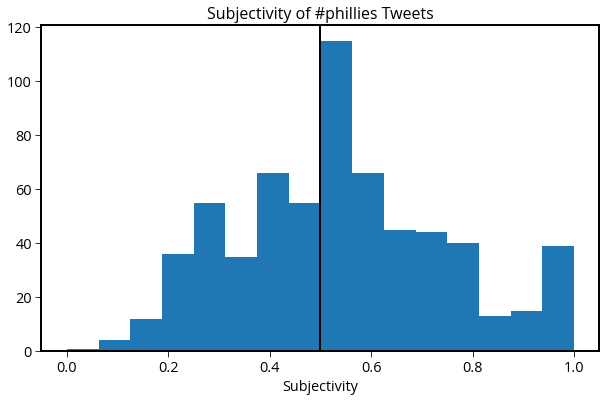

```python
# create a figure and axes
fig, ax = plt.subplots(figsize=(10, 6))

# histogram
ax.hist(biased['subjectivity'], bins='auto')
ax.axvline(x=0.5, c='k', lw=2)

# format
ax.set_xlabel("Subjectivity")
ax.set_title("Subjectivity of #phillies Tweets", fontsize=16);
```

## How does polarity influence subjectivity?

Are positive/negative tweets more or less objective?

## Seaborn's `regplot()` function

Is there a linear trend?

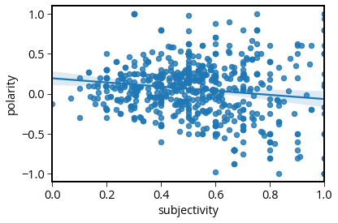

```python
ax = sns.regplot(x=biased['subjectivity'], y=biased['polarity'])
```

## Seaborn's `kdeplot()`

Shade the bivariate relationship

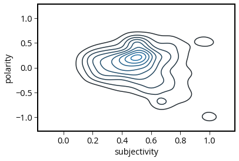

```python
ax = sns.kdeplot(data=biased['subjectivity'], data2=biased['polarity'])
```

**Insight**: the most subjective tweets tend to be most polarized as well...

## Let's check for hourly trends too

We can plot the distribution of polarity by the tweet's hour

First, we'll add a new column that gives the day and hour of the tweet.

We can use the built-in [strftime()](http://strftime.org/) function.

```python
# this is month/day hour AM/PM
biased['date_string'] = biased['date'].dt.strftime("%-m/%d %I %p")
```

```python
biased.head()
```

|  | date | polarity | subjectivity | text | date_string |
| --- | --- | --- | --- | --- | --- |
| 0 | 2020-10-01 00:59:44 | 0.350000 | 0.550000 | Filly en' full affect I see .. #phillies | 10/01 12 AM |
| 1 | 2020-10-01 00:50:00 | 0.211111 | 0.600000 | Philadelphia Phillies Trading Cards with FREE ... | 10/01 12 AM |
| 2 | 2020-09-30 23:57:55 | -0.700000 | 0.666667 | Whether he's bad or unlucky, #Phillies must ho... | 9/30 11 PM |
| 3 | 2020-09-30 23:35:18 | -0.234375 | 0.500000 | @phillies you need GM Benny breeze to fix your... | 9/30 11 PM |
| 5 | 2020-09-30 23:24:59 | 0.188973 | 0.544108 | New Pod is up: When/Will the #Eagles pull the ... | 9/30 11 PM |

Sort the tweets in chronological order...

```python
biased = biased.sort_values(by='date', ascending=True)
```

## Make a box and whiskers plot of the polarity

Use Seaborn's `boxplot()` function

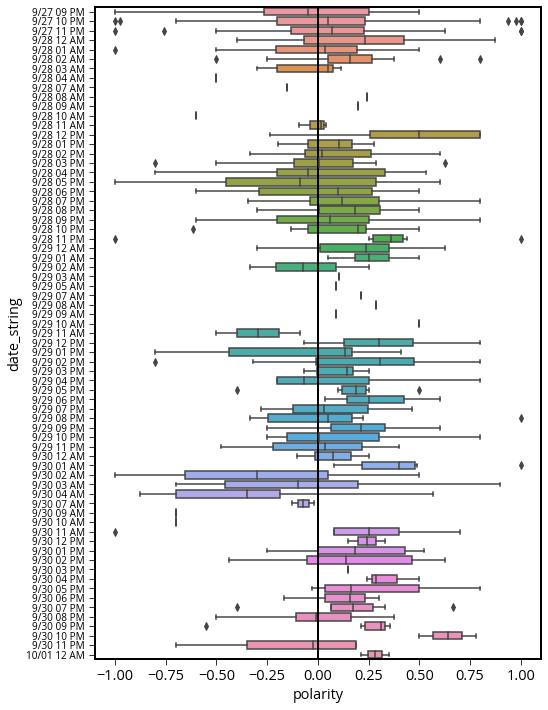

```python
ax = sns.boxplot(y='date_string', x='polarity', data=biased)
ax.axvline(x=0, c='k', lw=2) # neutral

# format
plt.setp(ax.get_yticklabels(), fontsize=10)
ax.figure.set_size_inches((8,12))
```

## And subjectivity over time...

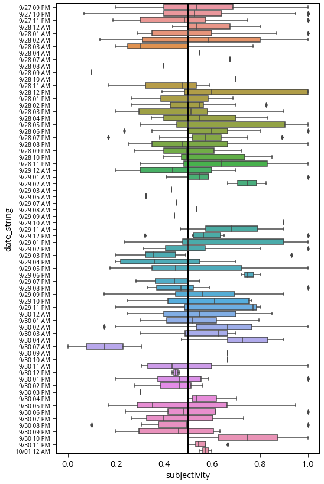

```python
ax = sns.boxplot(y='date_string', x='subjectivity', data=biased)
ax.axvline(x=0.5, c='k', lw=2) # neutral

# format
plt.setp(ax.get_yticklabels(), fontsize=10)
ax.figure.set_size_inches((8,14))
```

## At home exercise: sentiment analysis

Analyze your set of tweets from the last exercise (or get a new set), and explore the sentiments by:

- plotting histograms of the subjectivity and polarity
- finding the most/least subjective and polarized tweets
- plotting the relationship between polarity and subjectivity
- showing hourly trends in polarity/subjectivity

Or explore trends in some new way!

## That's it!

- Next week: creating your own datasets through web scraping
- Pre-recorded lecture will be posted on Sunday/Monday
- See you next Thursday!